# Spatial Analysis

2024-07-01

## Spatial Analysis

First, this plot shows the length and weight of all species from the trawl survey, divided by their EPU and decade. The Mid-Atlantic Bight EPU plot clearly shows a different pattern than the other EPUs. The data in these plots were restricted to weights less than 750 (still unsure what the units are - is it kg?), as it appeared all points above this value were data errors (extreme outliers).

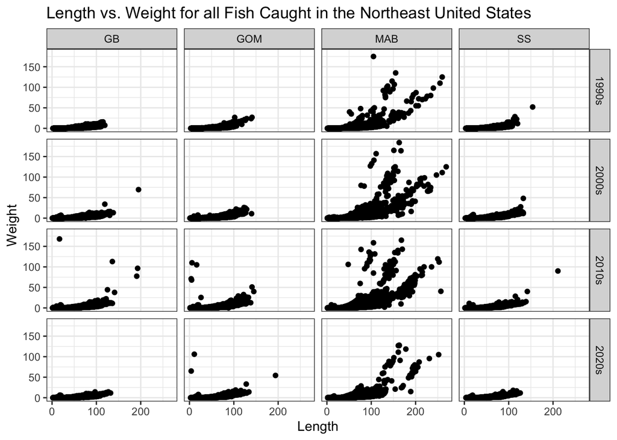

All coefficients in the model predicting log(weight) from log(length) are very significant when we add in the interactions between log(length) and decade and log(length) and EPU.

```
##
## Call:
## lm(formula = log(INDWT) ~ log(LENGTH) * decade + log(LENGTH) *
##     EPU, data = lw_spatial)
##
## Residuals:
##     Min      1Q  Median      3Q     Max
## -4.3229 -0.3973 -0.0740  0.2866  9.7134
##
## Coefficients:
##                           Estimate Std. Error t value Pr(>|t|)
## (Intercept)             -10.836880   0.014679 -738.26   <2e-16 ***
## log(LENGTH)               2.743001   0.004248  645.73   <2e-16 ***
## decade2000s               1.636364   0.013489  121.31   <2e-16 ***
## decade2010s               1.897697   0.013592  139.62   <2e-16 ***
## decade2020s               1.874128   0.018779   99.80   <2e-16 ***
## EPUGOM                    0.817741   0.013945   58.64   <2e-16 ***
## EPUMAB                   -0.222076   0.013100  -16.95   <2e-16 ***
## EPUSS                     1.745069   0.018503   94.31   <2e-16 ***
## log(LENGTH):decade2000s  -0.430031   0.003971 -108.30   <2e-16 ***
## log(LENGTH):decade2010s  -0.495278   0.003991 -124.09   <2e-16 ***
## log(LENGTH):decade2020s  -0.477390   0.005579  -85.57   <2e-16 ***
## log(LENGTH):EPUGOM       -0.247155   0.004093  -60.38   <2e-16 ***
## log(LENGTH):EPUMAB        0.054520   0.003862   14.12   <2e-16 ***
## log(LENGTH):EPUSS        -0.467448   0.005391  -86.72   <2e-16 ***
## ---
## Signif. codes:  0 '***' 0.001 '**' 0.01 '*' 0.05 '.' 0.1 ' ' 1
##
## Residual standard error: 0.7836 on 885934 degrees of freedom
## Multiple R-squared:  0.7513, Adjusted R-squared:  0.7513
## F-statistic: 2.059e+05 on 13 and 885934 DF,  p-value: < 2.2e-16
```

## Gulf of Maine Model

When the data is filtered to consider only fish caught in the Gulf of Maine, all coefficients continue to be very significant. This data was limited to individual weights below 60 as all points above were extreme outliers/likely data errors. It isn’t very easy to detect a pattern when looking at all species, so we’ll analyze the four species selected in earlier analyses: Atlantic cod, American plaice, Atlantic herring, and spiny dogfish.

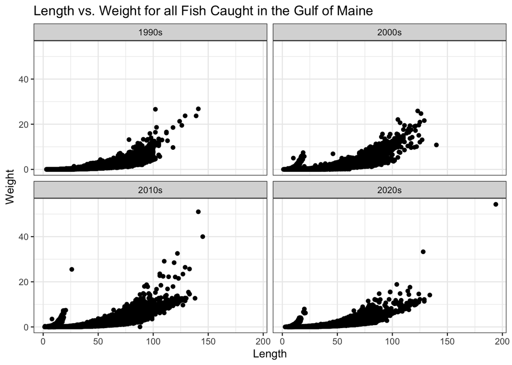

```
##
## Call:
## lm(formula = log(INDWT) ~ log(LENGTH) * decade, data = gom)
##
## Residuals:
##     Min      1Q  Median      3Q     Max
## -4.0833 -0.4369 -0.1006  0.3006  5.8185
##
## Coefficients:
##                           Estimate Std. Error t value Pr(>|t|)
## (Intercept)             -11.352480   0.024781 -458.11   <2e-16 ***
## log(LENGTH)               2.878176   0.007259  396.50   <2e-16 ***
## decade2000s               3.455535   0.029631  116.62   <2e-16 ***
## decade2010s               3.419951   0.028811  118.70   <2e-16 ***
## decade2020s               2.553322   0.041175   62.01   <2e-16 ***
## log(LENGTH):decade2000s  -0.956077   0.008754 -109.22   <2e-16 ***
## log(LENGTH):decade2010s  -0.930752   0.008483 -109.72   <2e-16 ***
## log(LENGTH):decade2020s  -0.673983   0.012122  -55.60   <2e-16 ***
## ---
## Signif. codes:  0 '***' 0.001 '**' 0.01 '*' 0.05 '.' 0.1 ' ' 1
##
## Residual standard error: 0.8583 on 311637 degrees of freedom
## Multiple R-squared:  0.6433, Adjusted R-squared:  0.6433
## F-statistic: 8.03e+04 on 7 and 311637 DF,  p-value: < 2.2e-16
```

## Atlantic Cod

From the plot, it looks like cod in the Gulf of Maine are growing to larger sizes, especially compared to the Mid-Atlantic Bight. The abundance caught per region also appears to differ, and this factor could contribute to the slight difference observed in the trends for each EPU.

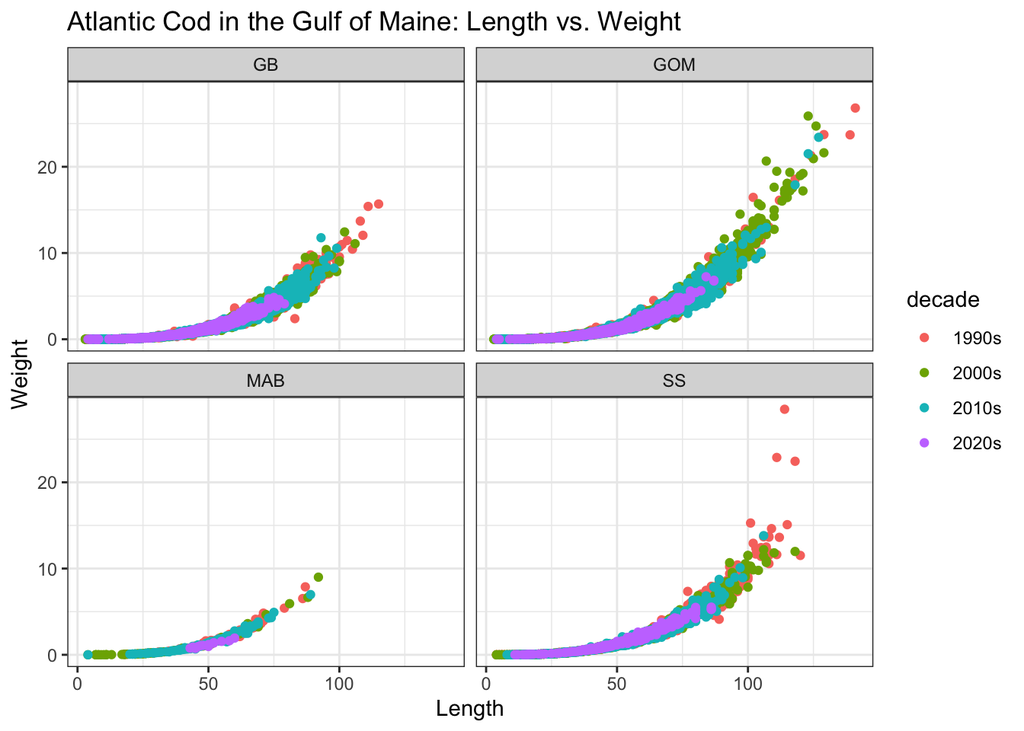

When considering all regions, the 2010s and 2020s are not significantly different from the 1990s. We do see that the weights of cod at their mean length vary significantly between both EPUs and decades.

```
##
## Call:
## lm(formula = log(INDWT) ~ log(LENGTH) * EPU + log(LENGTH) * decade,
##     data = cod)
##
## Residuals:
##      Min       1Q   Median       3Q      Max
## -1.33978 -0.07013  0.00094  0.06926  1.68205
##
## Coefficients:
##                           Estimate Std. Error  t value Pr(>|t|)
## (Intercept)             -11.729487   0.016387 -715.773  < 2e-16 ***
## log(LENGTH)               3.048836   0.004233  720.270  < 2e-16 ***
## EPUGOM                   -0.249733   0.013619  -18.337  < 2e-16 ***
## EPUMAB                   -0.043271   0.055699   -0.777  0.43724
## EPUSS                    -0.140282   0.020616   -6.804 1.04e-11 ***
## decade2000s              -0.044048   0.016521   -2.666  0.00768 **
## decade2010s               0.020677   0.018212    1.135  0.25624
## decade2020s               0.004071   0.031549    0.129  0.89733
## log(LENGTH):EPUGOM        0.072917   0.003552   20.531  < 2e-16 ***
## log(LENGTH):EPUMAB        0.027922   0.014705    1.899  0.05760 .
## log(LENGTH):EPUSS         0.031040   0.005267    5.893 3.83e-09 ***
## log(LENGTH):decade2000s   0.003524   0.004292    0.821  0.41157
## log(LENGTH):decade2010s  -0.008678   0.004712   -1.842  0.06555 .
## log(LENGTH):decade2020s   0.003260   0.008293    0.393  0.69420
## ---
## Signif. codes:  0 '***' 0.001 '**' 0.01 '*' 0.05 '.' 0.1 ' ' 1
##
## Residual standard error: 0.1197 on 27048 degrees of freedom
## Multiple R-squared:  0.9929, Adjusted R-squared:  0.9928
## F-statistic: 2.89e+05 on 13 and 27048 DF,  p-value: < 2.2e-16
```

```
## LENGTH = 49.5:
##  contrast  estimate      SE    df t.ratio p.value
##  GB - GOM   -0.0347 0.00168 27048 -20.653  <.0001
##  GB - MAB   -0.0657 0.00801 27048  -8.195  <.0001
##  GB - SS     0.0192 0.00230 27048   8.353  <.0001
##  GOM - MAB  -0.0309 0.00798 27048  -3.877  0.0006
##  GOM - SS    0.0539 0.00215 27048  25.028  <.0001
##  MAB - SS    0.0848 0.00812 27048  10.446  <.0001
##
## Results are averaged over the levels of: decade
## Results are given on the log (not the response) scale.
## P value adjustment: tukey method for comparing a family of 4 estimates
```

```
## LENGTH = 49.5:
##  contrast      estimate      SE    df t.ratio p.value
##  1990s - 2000s   0.0303 0.00207 27048  14.605  <.0001
##  1990s - 2010s   0.0132 0.00201 27048   6.558  <.0001
##  1990s - 2020s  -0.0168 0.00345 27048  -4.868  <.0001
##  2000s - 2010s  -0.0171 0.00174 27048  -9.828  <.0001
##  2000s - 2020s  -0.0471 0.00331 27048 -14.227  <.0001
##  2010s - 2020s  -0.0300 0.00327 27048  -9.175  <.0001
##
## Results are averaged over the levels of: EPU
## Results are given on the log (not the response) scale.
## P value adjustment: tukey method for comparing a family of 4 estimates
```

Model containing data from only cod in the Gulf of Maine: all terms appear to be significant.

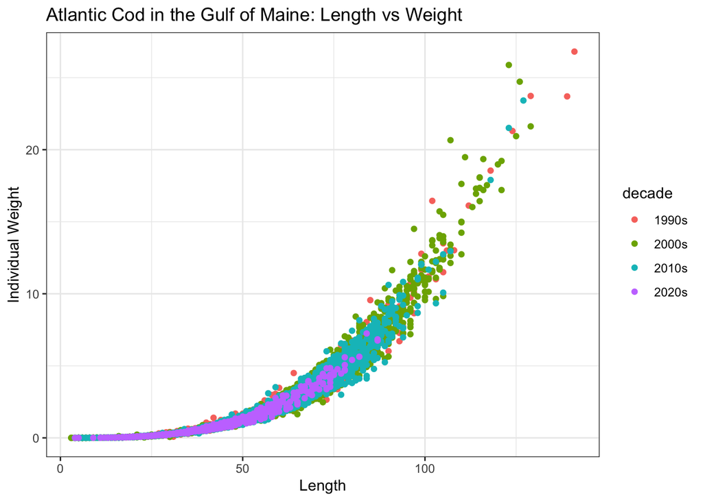

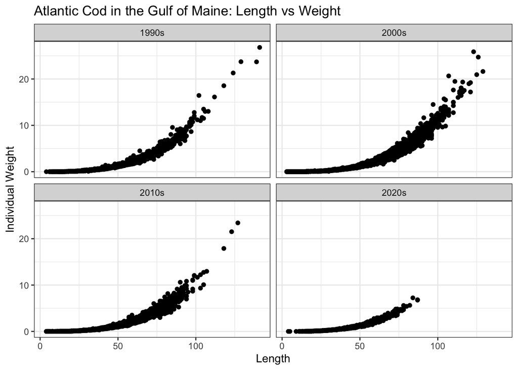

```
##
## Call:
## lm(formula = log(INDWT) ~ log(LENGTH) * decade, data = cod_gom)
##
## Residuals:
##      Min       1Q   Median       3Q      Max
## -1.34024 -0.06951  0.00058  0.06913  1.70007
##
## Coefficients:
##                           Estimate Std. Error  t value Pr(>|t|)
## (Intercept)             -11.981314   0.020564 -582.630  < 2e-16 ***
## log(LENGTH)               3.119827   0.005421  575.522  < 2e-16 ***
## decade2000s              -0.068792   0.023658   -2.908  0.00365 **
## decade2010s               0.073276   0.026084    2.809  0.00497 **
## decade2020s               0.121797   0.047908    2.542  0.01102 *
## log(LENGTH):decade2000s   0.013477   0.006241    2.159  0.03083 *
## log(LENGTH):decade2010s  -0.018635   0.006833   -2.727  0.00639 **
## log(LENGTH):decade2020s  -0.032993   0.012837   -2.570  0.01018 *
## ---
## Signif. codes:  0 '***' 0.001 '**' 0.01 '*' 0.05 '.' 0.1 ' ' 1
##
## Residual standard error: 0.1189 on 14247 degrees of freedom
## Multiple R-squared:  0.993,  Adjusted R-squared:  0.9929
## F-statistic: 2.867e+05 on 7 and 14247 DF,  p-value: < 2.2e-16
```

We also see that the only significant differences in weight at the mean length occur between the 1990s and 2000s and the 2000s and 2010s.

```
## LENGTH = 48:
##  contrast      estimate      SE    df t.ratio p.value
##  1990s - 2000s  0.01662 0.00289 14247   5.750  <.0001
##  1990s - 2010s -0.00113 0.00286 14247  -0.396  0.9789
##  1990s - 2020s  0.00593 0.00536 14247   1.107  0.6853
##  2000s - 2010s -0.01775 0.00232 14247  -7.644  <.0001
##  2000s - 2020s -0.01068 0.00510 14247  -2.097  0.1541
##  2010s - 2020s  0.00707 0.00508 14247   1.392  0.5045
##
## Results are given on the log (not the response) scale.
## P value adjustment: tukey method for comparing a family of 4 estimates
```

## American Plaice

We see that most American plaice are caught in the Gulf of Maine and very few are landed in the Mid-Atlantic Bight. The general trend of the data is similar for all EPUs.

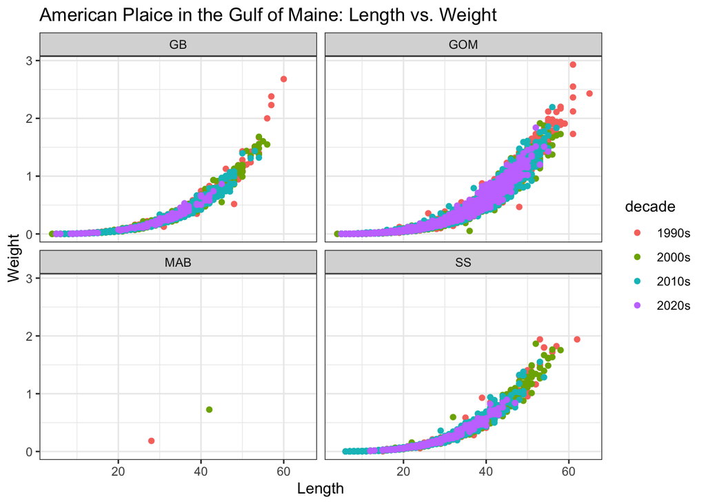

In the model including EPUs, we see some significant coefficients. Barely any data exists for the MAB region and thus it makes sense that the related terms are insignificant. We see that the mean length of American plaice in the Gulf of Maine significantly differs from fish in other EPUs (not including the MAB, since there is insufficient data). American plaice weight at their mean length also significantly differs across decades for all individuals caught in these EPUs.

```
##
## Call:
## lm(formula = log(INDWT) ~ log(LENGTH) * EPU + log(LENGTH) * decade,
##     data = plaice)
##
## Residuals:
##      Min       1Q   Median       3Q      Max
## -2.02165 -0.08465 -0.00388  0.07816  1.44770
##
## Coefficients:
##                           Estimate Std. Error  t value Pr(>|t|)
## (Intercept)             -12.439674   0.026532 -468.852  < 2e-16 ***
## log(LENGTH)               3.211659   0.007869  408.120  < 2e-16 ***
## EPUGOM                   -0.386040   0.024482  -15.768  < 2e-16 ***
## EPUMAB                   -0.963314   1.642063   -0.587   0.5574
## EPUSS                    -0.227451   0.031879   -7.135 9.86e-13 ***
## decade2000s              -0.184881   0.018258  -10.126  < 2e-16 ***
## decade2010s               0.017896   0.016831    1.063   0.2877
## decade2020s               0.023164   0.026806    0.864   0.3875
## log(LENGTH):EPUGOM        0.111212   0.007251   15.338  < 2e-16 ***
## log(LENGTH):EPUMAB        0.302581   0.463767    0.652   0.5141
## log(LENGTH):EPUSS         0.067316   0.009575    7.030 2.10e-12 ***
## log(LENGTH):decade2000s   0.035106   0.005530    6.349 2.20e-10 ***
## log(LENGTH):decade2010s  -0.009698   0.005079   -1.909   0.0562 .
## log(LENGTH):decade2020s  -0.003241   0.008103   -0.400   0.6892
## ---
## Signif. codes:  0 '***' 0.001 '**' 0.01 '*' 0.05 '.' 0.1 ' ' 1
##
## Residual standard error: 0.1329 on 38343 degrees of freedom
## Multiple R-squared:  0.9883, Adjusted R-squared:  0.9883
## F-statistic: 2.482e+05 on 13 and 38343 DF,  p-value: < 2.2e-16
```

```
## LENGTH = 28:
##  contrast  estimate      SE    df t.ratio p.value
##  GB - GOM   0.01533 0.00254 38343   6.043  <.0001
##  GB - MAB  -0.04532 0.13257 38343  -0.342  0.9863
##  GB - SS    0.00306 0.00341 38343   0.896  0.8067
##  GOM - MAB -0.06064 0.13255 38343  -0.457  0.9682
##  GOM - SS  -0.01227 0.00253 38343  -4.853  <.0001
##  MAB - SS   0.04837 0.13257 38343   0.365  0.9834
##
## Results are averaged over the levels of: decade
## Results are given on the log (not the response) scale.
## P value adjustment: tukey method for comparing a family of 4 estimates
```

```
## LENGTH = 28:
##  contrast      estimate      SE    df t.ratio p.value
##  1990s - 2000s   0.0679 0.00195 38343  34.780  <.0001
##  1990s - 2010s   0.0144 0.00182 38343   7.909  <.0001
##  1990s - 2020s  -0.0124 0.00301 38343  -4.100  0.0002
##  2000s - 2010s  -0.0534 0.00166 38343 -32.166  <.0001
##  2000s - 2020s  -0.0802 0.00292 38343 -27.486  <.0001
##  2010s - 2020s  -0.0268 0.00283 38343  -9.462  <.0001
##
## Results are averaged over the levels of: EPU
## Results are given on the log (not the response) scale.
## P value adjustment: tukey method for comparing a family of 4 estimates
```

American plaice model for the Gulf of Maine only: the distributions look slightly different by decade. This can be seen much more easily in the colored plot.

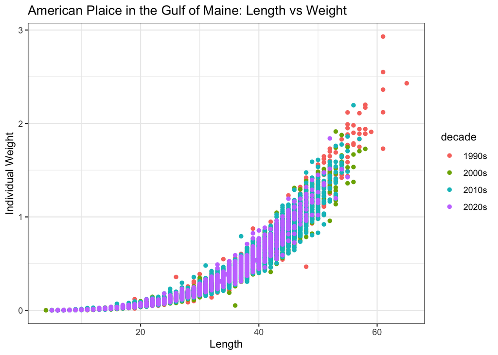

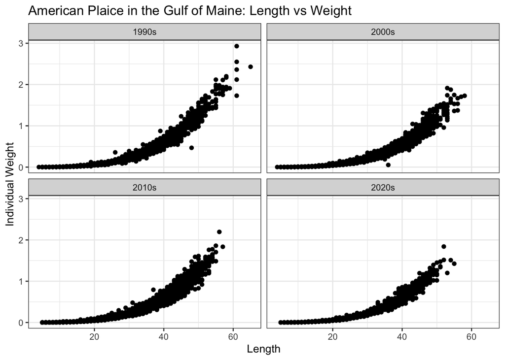

There is only a significant difference in the slope in the 2000s for American plaice in the Gulf of Maine. However, their weight at the mean length differs significantly in each decade.

```
##
## Call:
## lm(formula = log(INDWT) ~ log(LENGTH) * decade, data = plaice_gom)
##
## Residuals:
##      Min       1Q   Median       3Q      Max
## -1.97333 -0.08527 -0.00353  0.07933  1.45455
##
## Coefficients:
##                           Estimate Std. Error  t value Pr(>|t|)
## (Intercept)             -12.821721   0.015851 -808.881  < 2e-16 ***
## log(LENGTH)               3.321450   0.004778  695.222  < 2e-16 ***
## decade2000s              -0.196299   0.020431   -9.608  < 2e-16 ***
## decade2010s               0.019854   0.018606    1.067    0.286
## decade2020s               0.021394   0.029027    0.737    0.461
## log(LENGTH):decade2000s   0.036935   0.006206    5.952 2.68e-09 ***
## log(LENGTH):decade2010s  -0.008838   0.005620   -1.573    0.116
## log(LENGTH):decade2020s  -0.001841   0.008787   -0.209    0.834
## ---
## Signif. codes:  0 '***' 0.001 '**' 0.01 '*' 0.05 '.' 0.1 ' ' 1
##
## Residual standard error: 0.1345 on 32055 degrees of freedom
## Multiple R-squared:  0.9882, Adjusted R-squared:  0.9882
## F-statistic: 3.826e+05 on 7 and 32055 DF,  p-value: < 2.2e-16
```

```
## LENGTH = 27.9:
##  contrast      estimate      SE    df t.ratio p.value
##  1990s - 2000s  0.07339 0.00219 32055  33.489  <.0001
##  1990s - 2010s  0.00956 0.00202 32055   4.735  <.0001
##  1990s - 2020s -0.01527 0.00327 32055  -4.672  <.0001
##  2000s - 2010s -0.06383 0.00185 32055 -34.510  <.0001
##  2000s - 2020s -0.08865 0.00317 32055 -27.997  <.0001
##  2010s - 2020s -0.02483 0.00305 32055  -8.141  <.0001
##
## Results are given on the log (not the response) scale.
## P value adjustment: tukey method for comparing a family of 4 estimates
```

## Atlantic Herring

The Atlantic herring data was filtered to only contain weights below 0.75, as all weights recorded above were extreme outliers. The trends appear to differ slightly by EPU, especially between the Gulf of Maine and Mid-Atlantic Bight regions.

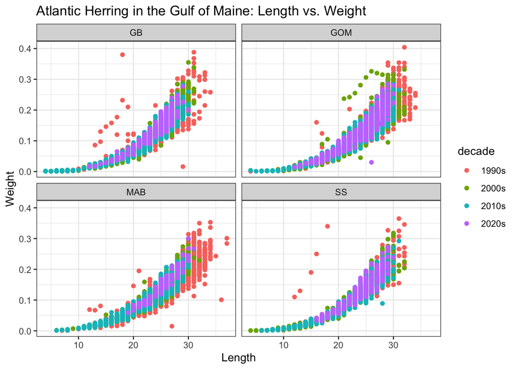

```
##
## Call:
## lm(formula = log(INDWT) ~ log(LENGTH) * EPU + log(LENGTH) * decade,
##     data = herring)
##
## Residuals:
##      Min       1Q   Median       3Q      Max
## -2.58951 -0.07395  0.00654  0.08228  2.18890
##
## Coefficients:
##                           Estimate Std. Error  t value Pr(>|t|)
## (Intercept)             -11.967743   0.026661 -448.880  < 2e-16 ***
## log(LENGTH)               3.095091   0.008534  362.675  < 2e-16 ***
## EPUGOM                    0.069232   0.025465    2.719  0.00656 **
## EPUMAB                    0.504444   0.027935   18.058  < 2e-16 ***
## EPUSS                    -0.225508   0.030121   -7.487 7.18e-14 ***
## decade2000s              -0.321198   0.023953  -13.409  < 2e-16 ***
## decade2010s              -0.133383   0.022800   -5.850 4.94e-09 ***
## decade2020s               0.179595   0.070230    2.557  0.01055 *
## log(LENGTH):EPUGOM       -0.028558   0.008152   -3.503  0.00046 ***
## log(LENGTH):EPUMAB       -0.176641   0.008936  -19.768  < 2e-16 ***
## log(LENGTH):EPUSS         0.068398   0.009724    7.034 2.04e-12 ***
## log(LENGTH):decade2000s   0.108200   0.007614   14.210  < 2e-16 ***
## log(LENGTH):decade2010s   0.050793   0.007295    6.963 3.38e-12 ***
## log(LENGTH):decade2020s  -0.036073   0.022152   -1.628  0.10344
## ---
## Signif. codes:  0 '***' 0.001 '**' 0.01 '*' 0.05 '.' 0.1 ' ' 1
##
## Residual standard error: 0.1368 on 49216 degrees of freedom
## Multiple R-squared:   0.96,  Adjusted R-squared:   0.96
## F-statistic: 9.078e+04 on 13 and 49216 DF,  p-value: < 2.2e-16
```

```
## LENGTH = 23.3:
##  contrast  estimate      SE    df t.ratio p.value
##  GB - GOM    0.0207 0.00190 49216  10.914  <.0001
##  GB - MAB    0.0520 0.00199 49216  26.145  <.0001
##  GB - SS     0.0101 0.00264 49216   3.805  0.0008
##  GOM - MAB   0.0312 0.00147 49216  21.246  <.0001
##  GOM - SS   -0.0107 0.00226 49216  -4.717  <.0001
##  MAB - SS   -0.0419 0.00236 49216 -17.732  <.0001
##
## Results are averaged over the levels of: decade
## Results are given on the log (not the response) scale.
## P value adjustment: tukey method for comparing a family of 4 estimates
```

```
## LENGTH = 23.3:
##  contrast      estimate      SE    df t.ratio p.value
##  1990s - 2000s -0.01962 0.00166 49216 -11.827  <.0001
##  1990s - 2010s -0.02661 0.00166 49216 -16.053  <.0001
##  1990s - 2020s -0.06597 0.00339 49216 -19.471  <.0001
##  2000s - 2010s -0.00699 0.00148 49216  -4.734  <.0001
##  2000s - 2020s -0.04635 0.00329 49216 -14.110  <.0001
##  2010s - 2020s -0.03936 0.00327 49216 -12.050  <.0001
##
## Results are averaged over the levels of: EPU
## Results are given on the log (not the response) scale.
## P value adjustment: tukey method for comparing a family of 4 estimates
```

Model including only herring from the Gulf of Maine: the distributions appear to differ across decades. This can be more clearly observed in the faceted plots. There were no herrings surveyed in the 2020s that were as small as some from the past decades. Many herring were reported as weighing 0.001 in earlier decades - this may be an error, or maybe fewer small herring have been caught in these surveys in more recent years.

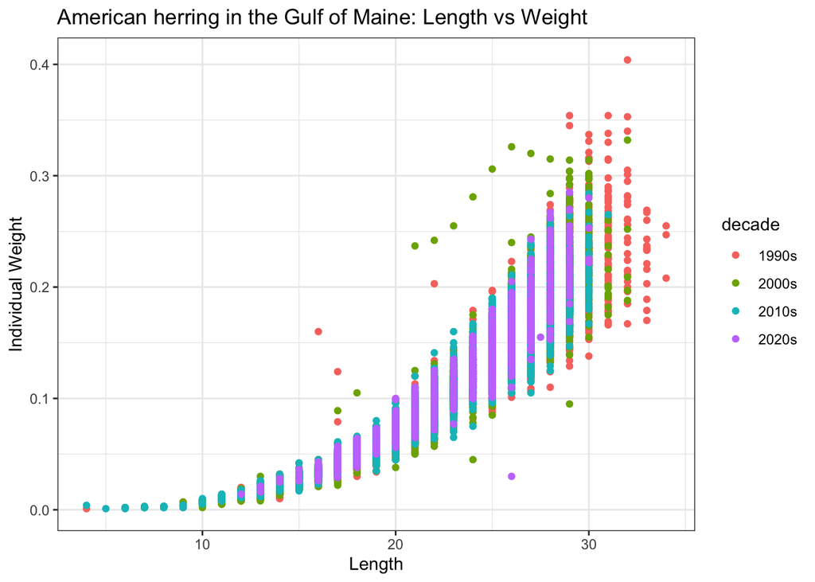

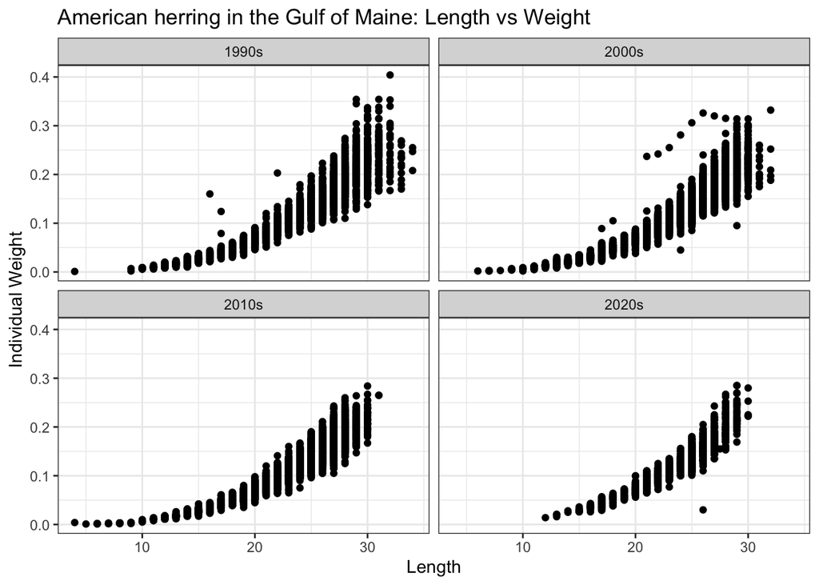

Model including only Atlantic herring from the Gulf of Maine: all coefficients are very significant. Their weight at the mean length is significantly different across all decades as well.

```
##
## Call:
## lm(formula = log(INDWT) ~ log(LENGTH) * decade, data = herring_gom)
##
## Residuals:
##      Min       1Q   Median       3Q      Max
## -1.64857 -0.07477  0.00149  0.08017  2.13188
##
## Coefficients:
##                           Estimate Std. Error  t value Pr(>|t|)
## (Intercept)             -12.078699   0.027506 -439.123  < 2e-16 ***
## log(LENGTH)               3.126047   0.008763  356.750  < 2e-16 ***
## decade2000s              -0.146562   0.036644   -4.000 6.36e-05 ***
## decade2010s               0.146272   0.035223    4.153 3.30e-05 ***
## decade2020s               0.419271   0.082005    5.113 3.20e-07 ***
## log(LENGTH):decade2000s   0.048588   0.011622    4.181 2.92e-05 ***
## log(LENGTH):decade2010s  -0.039341   0.011227   -3.504 0.000459 ***
## log(LENGTH):decade2020s  -0.117715   0.025944   -4.537 5.73e-06 ***
## ---
## Signif. codes:  0 '***' 0.001 '**' 0.01 '*' 0.05 '.' 0.1 ' ' 1
##
## Residual standard error: 0.1307 on 21592 degrees of freedom
## Multiple R-squared:  0.9596, Adjusted R-squared:  0.9595
## F-statistic: 7.319e+04 on 7 and 21592 DF,  p-value: < 2.2e-16
```

```
## LENGTH = 23.6:
##  contrast      estimate      SE    df t.ratio p.value
##  1990s - 2000s -0.00707 0.00261 21592  -2.709  0.0341
##  1990s - 2010s -0.02188 0.00254 21592  -8.620  <.0001
##  1990s - 2020s -0.04707 0.00425 21592 -11.065  <.0001
##  2000s - 2010s -0.01482 0.00206 21592  -7.194  <.0001
##  2000s - 2020s -0.04001 0.00399 21592 -10.035  <.0001
##  2010s - 2020s -0.02519 0.00394 21592  -6.391  <.0001
##
## Results are given on the log (not the response) scale.
## P value adjustment: tukey method for comparing a family of 4 estimates
```

## Spiny Dogfish

The spiny dogfish data follow a similar trend in all EPUs with some slight variation in the extremity of differences by decade.

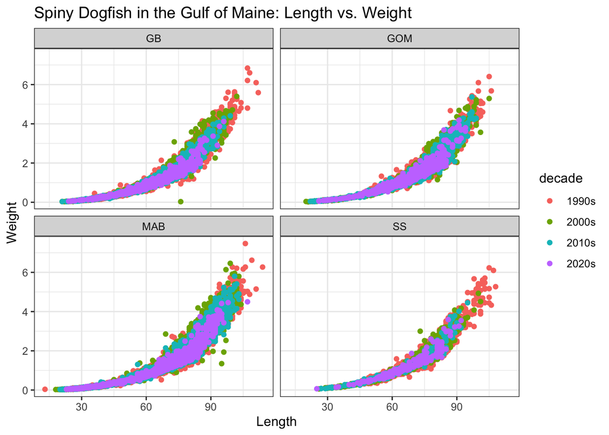

In the all-EPU model for spiny dogfish, all decadal terms are significant. Spiny dogfish in other EPUs have a significantly different mean length than spiny dogfish in the Gulf of Maine. Weight at mean length for all spiny dogfish (all EPUs considered) are also significantly different in each decade.

```
##
## Call:
## lm(formula = log(INDWT) ~ log(LENGTH) * EPU + log(LENGTH) * decade,
##     data = dogfish)
##
## Residuals:
##     Min      1Q  Median      3Q     Max
## -4.0851 -0.0892 -0.0039  0.0848  1.7510
##
## Coefficients:
##                           Estimate Std. Error  t value Pr(>|t|)
## (Intercept)             -12.816783   0.024127 -531.213  < 2e-16 ***
## log(LENGTH)               3.091505   0.005792  533.776  < 2e-16 ***
## EPUGOM                   -0.096256   0.033998   -2.831 0.004639 **
## EPUMAB                   -0.317951   0.025018  -12.709  < 2e-16 ***
## EPUSS                    -0.080752   0.051761   -1.560 0.118746
## decade2000s              -0.089741   0.025086   -3.577 0.000348 ***
## decade2010s               0.101018   0.024755    4.081 4.50e-05 ***
## decade2020s               0.512793   0.043413   11.812  < 2e-16 ***
## log(LENGTH):EPUGOM        0.027700   0.008082    3.427 0.000610 ***
## log(LENGTH):EPUMAB        0.071750   0.005995   11.968  < 2e-16 ***
## log(LENGTH):EPUSS         0.015564   0.012263    1.269 0.204376
## log(LENGTH):decade2000s   0.022305   0.005928    3.763 0.000168 ***
## log(LENGTH):decade2010s  -0.027856   0.005927   -4.700 2.61e-06 ***
## log(LENGTH):decade2020s  -0.133343   0.010418  -12.800  < 2e-16 ***
## ---
## Signif. codes:  0 '***' 0.001 '**' 0.01 '*' 0.05 '.' 0.1 ' ' 1
##
## Residual standard error: 0.1323 on 41367 degrees of freedom
## Multiple R-squared:  0.9783, Adjusted R-squared:  0.9783
## F-statistic: 1.433e+05 on 13 and 41367 DF,  p-value: < 2.2e-16
```

```
## LENGTH = 68.9:
##  contrast   estimate      SE    df t.ratio p.value
##  GB - GOM  -0.020975 0.00194 41367 -10.798  <.0001
##  GB - MAB   0.014297 0.00176 41367   8.123  <.0001
##  GB - SS    0.014881 0.00256 41367   5.811  <.0001
##  GOM - MAB  0.035272 0.00164 41367  21.519  <.0001
##  GOM - SS   0.035856 0.00249 41367  14.386  <.0001
##  MAB - SS   0.000584 0.00235 41367   0.248  0.9947
##
## Results are averaged over the levels of: decade
## Results are given on the log (not the response) scale.
## P value adjustment: tukey method for comparing a family of 4 estimates
```

```
## LENGTH = 68.9:
##  contrast      estimate      SE    df t.ratio p.value
##  1990s - 2000s -0.00466 0.00153 41367  -3.040  0.0127
##  1990s - 2010s  0.01687 0.00186 41367   9.055  <.0001
##  1990s - 2020s  0.05153 0.00298 41367  17.275  <.0001
##  2000s - 2010s  0.02153 0.00194 41367  11.088  <.0001
##  2000s - 2020s  0.05619 0.00304 41367  18.490  <.0001
##  2010s - 2020s  0.03466 0.00321 41367  10.786  <.0001
##
## Results are averaged over the levels of: EPU
## Results are given on the log (not the response) scale.
## P value adjustment: tukey method for comparing a family of 4 estimates
```

For spiny dogfish in the Gulf of Maine specifically, we see some variability in each decade. Both plots illustrate this relatively well, but the colored plot likely shows it more clearly.

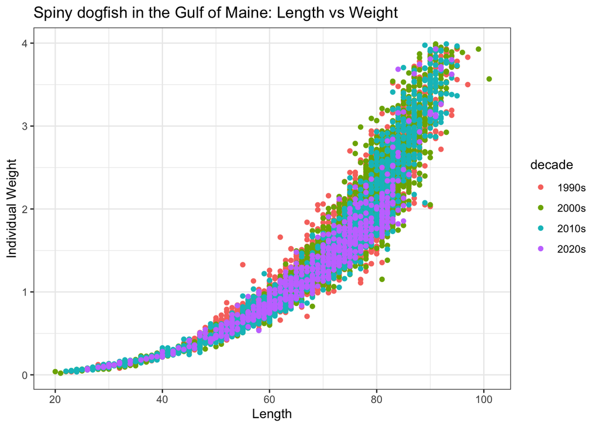

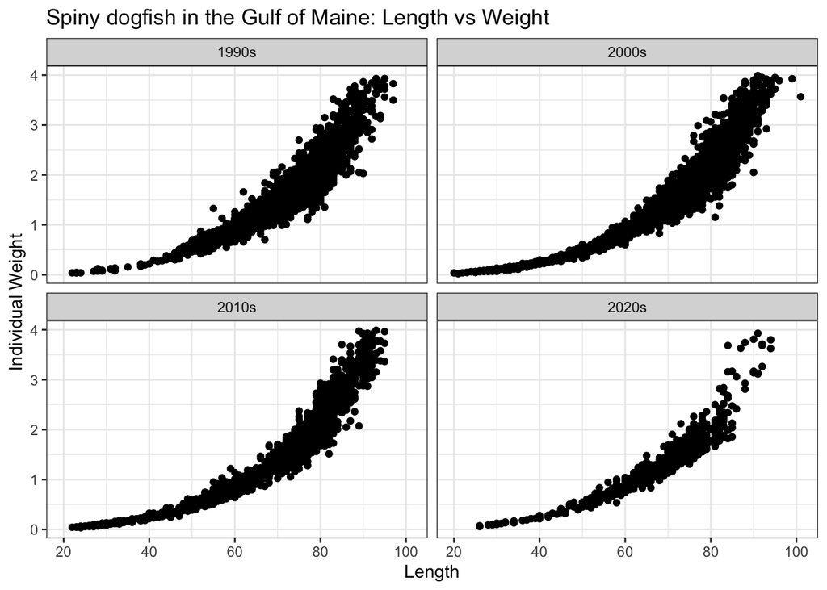

In the model considering only spiny dogfish in the Gulf of Maine, we see that all terms are very significant except the 2020s decade. This could be partially due to the fact that less data is being analyzed for the 2020s than the decades prior. Spiny dogfish weight at mean length is significantly different for all decades, however, indicating a shift in the distribution.

```
##
## Call:
## lm(formula = log(INDWT) ~ log(LENGTH) * decade, data = dogfish_gom)
##
## Residuals:
##      Min       1Q   Median       3Q      Max
## -0.64855 -0.08103 -0.00239  0.07823  0.66814
##
## Coefficients:
##                          Estimate Std. Error  t value Pr(>|t|)
## (Intercept)             -12.53199    0.05098 -245.832  < 2e-16 ***
## log(LENGTH)               3.03133    0.01204  251.818  < 2e-16 ***
## decade2000s              -0.50439    0.06409   -7.870 3.91e-15 ***
## decade2010s              -0.36352    0.06636   -5.478 4.39e-08 ***
## decade2020s               0.12555    0.11098    1.131    0.258
## log(LENGTH):decade2000s   0.11502    0.01510    7.619 2.77e-14 ***
## log(LENGTH):decade2010s   0.07808    0.01575    4.959 7.20e-07 ***
## log(LENGTH):decade2020s  -0.04154    0.02639   -1.574    0.116
## ---
## Signif. codes:  0 '***' 0.001 '**' 0.01 '*' 0.05 '.' 0.1 ' ' 1
##
## Residual standard error: 0.1207 on 10271 degrees of freedom
## Multiple R-squared:  0.9669, Adjusted R-squared:  0.9669
## F-statistic: 4.289e+04 on 7 and 10271 DF,  p-value: < 2.2e-16
```

```
## LENGTH = 70:
##  contrast      estimate      SE    df t.ratio p.value
##  1990s - 2000s   0.0157 0.00274 10271   5.725  <.0001
##  1990s - 2010s   0.0318 0.00346 10271   9.191  <.0001
##  1990s - 2020s   0.0509 0.00553 10271   9.217  <.0001
##  2000s - 2010s   0.0161 0.00351 10271   4.575  <.0001
##  2000s - 2020s   0.0353 0.00556 10271   6.337  <.0001
##  2010s - 2020s   0.0192 0.00595 10271   3.226  0.0069
##
## Results are given on the log (not the response) scale.
## P value adjustment: tukey method for comparing a family of 4 estimates
```

## All-species slope plot

[figure not shown]

When fish from all EPUs are included, we see this trend:

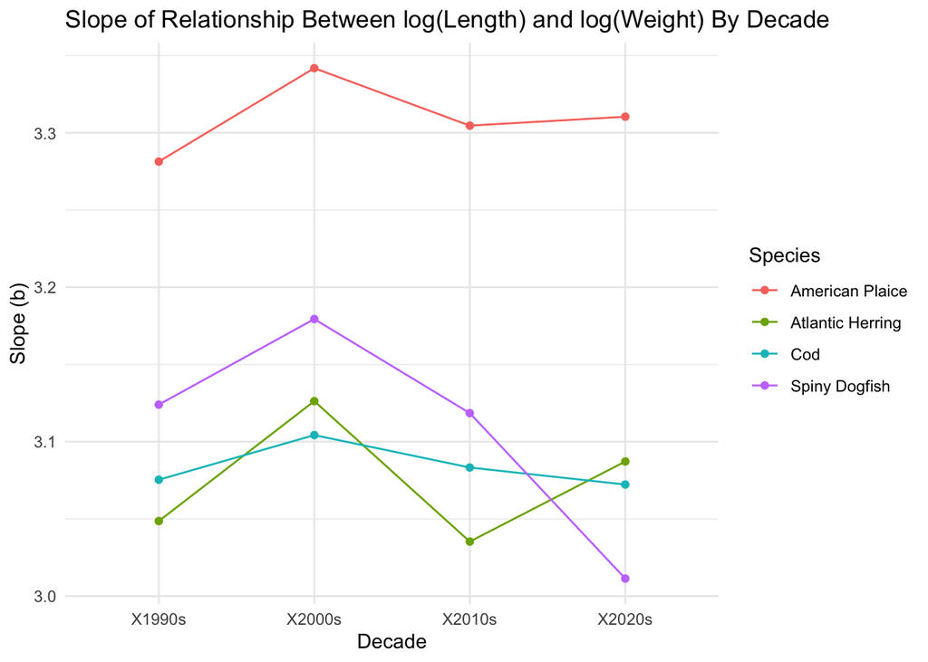